# Random Forest in Machine Learning

Foresight from the Forest

Author

Matt McGehee (Advisor: Dr. Seals)

Published

December 2, 2024

## Introduction

Machine learning, and specifically the Random Forest (RF) algorithm, has become a highly valuable tool in various domains, from customer and supplier segmentation to predicting outcomes in complex datasets. Random Forest’s robustness, accuracy, and ability to handle both classification and regression tasks make it ideal for data that contain noise, uncertainty, or complex relationships between variables.

This report synthesizes findings from six research articles, focusing on different aspects of machine learning applications using Random Forest. These include handling imbalanced data, supplier and customer segmentation, predicting customer retention, and leveraging online reviews for benefit segmentation. Each article emphasizes the flexibility and power of Random Forest in solving diverse problems across industries.

## Summary of Articles

The first article I reviewed compares two Random Forest-based algorithms: Random Credal Random Forest (RCRF) and Oblique Random Forest (oRF). Both models use bagging and feature randomness, but RCRF includes credal sets, which offer a range of probabilities, making the model more robust and accurate. This allows RCRF to handle noisy datasets better than oRF, while also improving computational efficiency. One limitation is the complexity of the credal set approach, which can add overhead to the model. [1]

The second article explored how Random Forest (RF) performs on imbalanced datasets. The authors analyzed the effect of different tree numbers and feature selections on classification performance, using Area Under the ROC Curve (AUC) as the primary metric. RF outperformed several other models, including Naive Bayes and SVM, and provided recommendations on parameter settings for improving accuracy when handling imbalanced data. The findings emphasize RF’s capability to handle this challenging dataset type more effectively than most conventional methods. [2]

The third article gave an in-depth review of Random Forest (RF), discussing how it works for both classification and regression tasks. RF creates multiple decision trees using subsets of the data and applies bagging to reduce variance and improve prediction accuracy. The article highlights RF’s ability to work with high-dimensional data while being resilient to overfitting. However, it also notes the difficulty of analyzing the algorithm due to its complex nature. [3]

Next, I looked at a study that used Random Forest to predict customer retention and profitability. The goal was to assess “next buy,” “partial defection,” and “profitability evolution” for a European financial services company. RF outperformed logistic regression, particularly when predicting customer retention based on total product ownership and cross-buying habits. Additionally, the study highlighted the importance of salespeople’s behavior in influencing customer outcomes. One downside is that RF, while accurate, can be challenging to interpret for business users without technical expertise. [4]

Another article focused on using Random Forest for supplier segmentation. This study aimed to identify core suppliers based on their impact on a buyer’s profitability using e-invoice data. The RF model performed well, achieving an AUC of 89.58%, which demonstrated its strong predictive ability. Automating supplier segmentation through RF improved accuracy and reduced human bias, making it a reliable method for procurement departments. However, the model’s accuracy is highly dependent on the quality of input data. [5]

Lastly, I examined a study on benefit segmentation using Random Forest with customer reviews from a hotel booking platform. The study used Non-Negative Matrix Factorization (NMF) to extract topics from reviews, then applied RF to classify the reviews based on benefits, such as business travel or leisure travel. RF achieved a precision of 81%, showcasing how it can effectively analyze text data for segmentation. The authors concluded that benefit segmentation with RF could help businesses tailor their products and services to specific customer needs, although it might require large datasets for optimal performance. [6]

## Data

The dataset, provided by a fellow student [7], contains sales transaction details from a B2B context. The data tracks information on sales orders, quantities ordered, shipping details, and item-level statuses. Below is the data definition table that explains the key attributes.

```r
data_def <- data.frame(
  Attribute = c("OPCO", "SalesOrderID", "CustomerPO", "Product", "Description",
                "Substrate", "RequestedDeliveryDate", "DateFulfilled",
                "qtyOrdered", "qtyFulfilled", "UnitPrice", "TotalPrice",
                "Class", "ShipToName", "ShipToAddress", "SalesOrderStatus", "SalesItemStatus"),
  Format = c("Varchar", "Numeric", "Numeric", "Varchar", "Varchar",
             "Varchar", "Date", "Date",
             "Numeric", "Numeric", "Numeric", "Numeric",
             "Varchar", "Varchar", "Varchar", "Varchar", "Varchar"),
  Description = c("The customer placing the order, typically a distributor.",
                  "Unique identifier assigned to each sales order.",
                  "Customer's identifier for their order, sent to BCC.",
                  "Unique identifier assigned to each product.",
                  "Description of the product being sold.",
                  "Type of product/material.",
                  "Date the delivery was scheduled originally.",
                  "Date the delivery was made.",
                  "Quantity ordered on the order.",
                  "Quantity delivered on the order.",
                  "Price of each case of product SSI charges the customer.",
                  "Total price of the sales order.",
                  "Customer name.",
                  "Name of the ordering party.",
                  "Address where the order needs to be delivered.",
                  "Status of sales order.",
                  "Status of each line item on the sales order.")
)

knitr::kable(data_def, caption = "Sales Transaction Dataset Definition", align = "l")
```

Sales Transaction Dataset Definition

| Attribute | Format | Description |
| --- | --- | --- |
| OPCO | Varchar | The customer placing the order, typically a distributor. |
| SalesOrderID | Numeric | Unique identifier assigned to each sales order. |
| CustomerPO | Numeric | Customer’s identifier for their order, sent to BCC. |
| Product | Varchar | Unique identifier assigned to each product. |
| Description | Varchar | Description of the product being sold. |
| Substrate | Varchar | Type of product/material. |
| RequestedDeliveryDate | Date | Date the delivery was scheduled originally. |
| DateFulfilled | Date | Date the delivery was made. |
| qtyOrdered | Numeric | Quantity ordered on the order. |
| qtyFulfilled | Numeric | Quantity delivered on the order. |
| UnitPrice | Numeric | Price of each case of product SSI charges the customer. |
| TotalPrice | Numeric | Total price of the sales order. |
| Class | Varchar | Customer name. |
| ShipToName | Varchar | Name of the ordering party. |
| ShipToAddress | Varchar | Address where the order needs to be delivered. |
| SalesOrderStatus | Varchar | Status of sales order. |
| SalesItemStatus | Varchar | Status of each line item on the sales order. |

### Summary Stats

```r
# Load the pander package
library(pander)

# Print a formatted summary of the dataset
pander(summary(sales_data), caption = "Summary Statistics of Sales Data")
```

Summary Statistics of Sales Data (continued below)

| OPCO | SalesOrderID | CustomerPO | Product |
| --- | --- | --- | --- |
| Length:33818 | Length:33818 | Length:33818 | Length:33818 |
| Class :character | Class :character | Class :character | Class :character |
| Mode :character | Mode :character | Mode :character | Mode :character |
| NA | NA | NA | NA |
| NA | NA | NA | NA |
| NA | NA | NA | NA |

Table continues below

| Description | Substrate | RequestedDeliveryDate | DateFulfilled |
| --- | --- | --- | --- |
| Length:33818 | Length:33818 | Length:33818 | Length:33818 |
| Class :character | Class :character | Class :character | Class :character |
| Mode :character | Mode :character | Mode :character | Mode :character |
| NA | NA | NA | NA |
| NA | NA | NA | NA |
| NA | NA | NA | NA |

Table continues below

| qtyOrdered | QuantityFulfilled | UnitPrice | TotalPrice |
| --- | --- | --- | --- |
| Min. : 1.00 | Min. : 0.00 | Min. :-23103.60 | Min. :-72000.0 |
| 1st Qu.: 6.00 | 1st Qu.: 6.00 | 1st Qu.: 36.49 | 1st Qu.: 349.4 |
| Median : 24.00 | Median : 24.00 | Median : 56.52 | Median : 1198.8 |
| Mean : 60.58 | Mean : 58.88 | Mean : 101.02 | Mean : 3024.1 |
| 3rd Qu.: 54.00 | 3rd Qu.: 50.00 | 3rd Qu.: 76.00 | 3rd Qu.: 2880.0 |
| Max. :23160.00 | Max. :23160.00 | Max. : 20283.46 | Max. :143084.7 |

Table continues below

| Class | ShipToName | ShipToAddress | SalesOrderStatus |
| --- | --- | --- | --- |
| Length:33818 | Length:33818 | Length:33818 | Length:33818 |
| Class :character | Class :character | Class :character | Class :character |
| Mode :character | Mode :character | Mode :character | Mode :character |
| NA | NA | NA | NA |
| NA | NA | NA | NA |
| NA | NA | NA | NA |

| SalesItemStatus |
| --- |
| Length:33818 |
| Class :character |
| Mode :character |
| NA |
| NA |
| NA |

This dataset allows for various analyses including:

- Order fulfillment performance: By comparing the qtyOrdered and qtyFulfilled attributes, and the RequestedDeliveryDate against the DateFulfilled, one can analyze how efficiently orders are being fulfilled and whether delivery deadlines are met.
- Sales trends and pricing: The UnitPrice and TotalPrice fields, alongside Product and Class, provide opportunities to evaluate product pricing strategies and customer buying patterns.
- Customer segmentation: With attributes like Class and ShipToName, you can analyze customer behavior and segment them based on order sizes, frequency, or geography.

This dataset provides a detailed overview of the company’s sales transactions. By leveraging these attributes, one can assess order performance, customer segmentation, and pricing strategies.

### Table 1

|  | Total Orders | Closed Short | Fulfilled |
| --- | --- | --- | --- |
|  | (n=7585) | (n=733) | (n=6852) |
| Top Customers |  |  |  |
| Smoothie Island | 1701 (22.43%) | 455 (62.07%) | 1246 (18.18%) |
| Philly Bite | 1556 (20.51%) | 267 (36.43%) | 1289 (18.81%) |
| PlatePioneers | 1396 (18.40%) | 143 (19.51%) | 1253 (18.29%) |
| Berl Company | 906 (11.94%) | 5 (0.68%) | 901 (13.15%) |
| DineLink Intl | 589 (7.77%) | 42 (5.73%) | 547 (7.98%) |
| Top Products |  |  |  |
| DC-01 | 1135 (14.96%) | 345 (47.07%) | 790 (11.53%) |
| TSC-PQB-01 | 1087 (14.33%) | 389 (53.07%) | 698 (10.19%) |
| TSC-PW14X16-01 | 848 (11.18%) | 283 (38.61%) | 565 (8.25%) |
| CMI-PCK-01 | 802 (10.57%) | 288 (39.29%) | 514 (7.50%) |
| PC-05-B1 | 745 (9.82%) | 220 (30.01%) | 525 (7.66%) |
| Top Distributors |  |  |  |
| Ed Don & Company - Miramar | 210 (2.77%) | 0 (0.00%) | 210 (3.06%) |
| PFG- Gainesville | 197 (2.60%) | 0 (0.00%) | 197 (2.88%) |
| Ed Don & Company - Woodridge | 186 (2.45%) | 0 (0.00%) | 186 (2.71%) |
| Ed Don & Company - Mira Loma | 180 (2.37%) | 0 (0.00%) | 180 (2.63%) |
| .Ed Don - Miramar | 162 (2.14%) | 0 (0.00%) | 162 (2.36%) |
| Top Substrates | Paper | Plastic | Bagasse |
| Revenue($103,826,286) | $54,838,585 (52.82%) | $40,336,669 (38.85%) | $4,350,337 (4.19%) |
| Quantity Ordered | Min | Mean | Max |
| Total Ordered(1,971,237) | 1 | 61.47 | 23,160 |
| Unit Price | Min | Mean | Max |
| Key Stats | $0.16 | $62.60 | $864.00 |
| Total Price | Min | Mean | Max |
| Key Stats | $4.92 | $3,430.74 | $143,084.74 |

### Data Visualizations

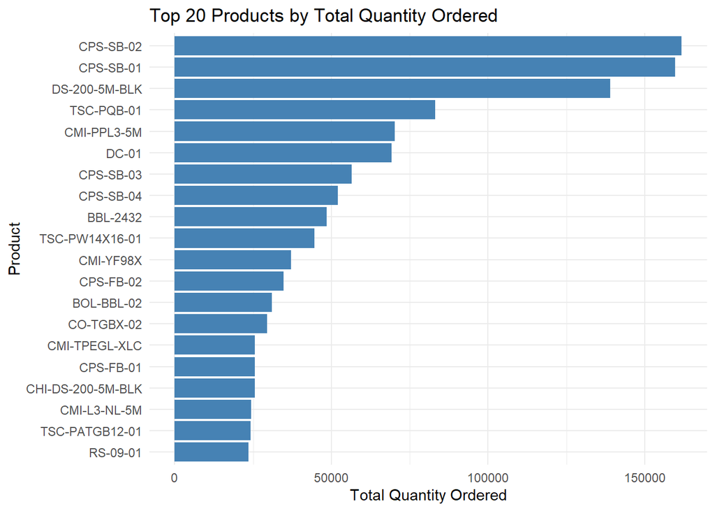

```r
library(ggplot2)
library(dplyr)

sales_data <- read.csv("data_as_csv.csv")

product_qty <- sales_data %>%
  group_by(Product) %>%
  summarise(TotalQuantityOrdered = sum(qtyOrdered, na.rm = TRUE)) %>%
  arrange(desc(TotalQuantityOrdered)) %>%
  slice(1:20)

ggplot(product_qty, aes(x = reorder(Product, TotalQuantityOrdered), y = TotalQuantityOrdered)) +
  geom_bar(stat = "identity", fill = "steelblue") +
  theme_minimal() +
  coord_flip() +
  labs(title = "Top 20 Products by Total Quantity Ordered", x = "Product", y = "Total Quantity Ordered")
```

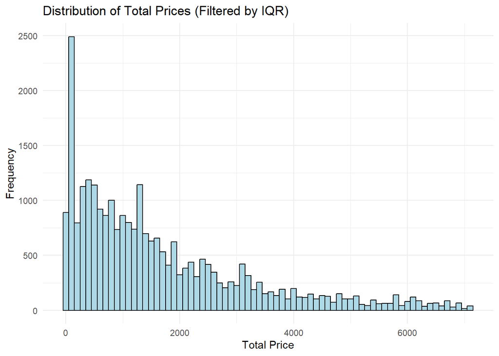

```r
library(ggplot2)
library(dplyr)

sales_data <- read.csv("data_as_csv.csv")

exclude_products <- c("OUTBOUND SHIPPING", "Outbound Shipping", "Shipping Charge", "SHIPPING CHARGE")

filtered_data <- sales_data %>%
  filter(TotalPrice > 0, !Product %in% exclude_products)

Q1 <- quantile(filtered_data$TotalPrice, 0.25, na.rm = TRUE)
Q3 <- quantile(filtered_data$TotalPrice, 0.75, na.rm = TRUE)
IQR_value <- IQR(filtered_data$TotalPrice, na.rm = TRUE)

lower_bound <- Q1 - 1.5 * IQR_value
upper_bound <- Q3 + 1.5 * IQR_value

filtered_data_IQR <- filtered_data %>%
  filter(TotalPrice >= lower_bound & TotalPrice <= upper_bound)

ggplot(filtered_data_IQR, aes(x = TotalPrice)) +
  geom_histogram(binwidth = 100, fill = "lightblue", color = "black") +
  theme_minimal() +
  labs(title = "Distribution of Total Prices (Filtered by IQR)", x = "Total Price", y = "Frequency")
```

## Methods

### Random Forest Classification

The Random Forest algorithm, initially proposed by Breiman (2001), is a widely used ensemble learning method for classification and regression tasks. It operates by constructing multiple decision trees during training and outputs the mode of the classes (for classification) or mean prediction (for regression) of the individual trees [8]. The following methods and descriptions have all been derived from G’erard Biau and Erwan Scornet’s paper “A random forest guided tour.” [3]

### Tree Building Process

1. **Bootstrap Sampling**: The algorithm selects a random subset of data with replacement from the training dataset to build each decision tree. This sampling technique is known as “bagging” (bootstrap aggregating) .
2. **Node Splitting**:
   - For regression analysis, the CART (Classification and Regression Trees) algorithm is used to evaluate splits:

     $$L_{\text{reg},n}(j, z) = \frac{1}{N_n(A)} \sum_{i=1}^{n} (Y_i - \bar{Y}_A)^2 \mathbf{1}_{X_i \in A} - \frac{1}{N_n(A)} \left(\sum_{i=1}^{n} (Y_i - \bar{Y}_{AL})^2 \mathbf{1}_{X_i \in AL} + \sum_{i=1}^{n} (Y_i - \bar{Y}_{AR})^2 \mathbf{1}_{X_i \in AR}\right)$$
     - $N_n(A)$: Number of data points in cell $A$.
     - $Y_i$: Response variable for observation $i$.
     - $\bar{Y}_A$: Mean of $Y_i$ in cell $A$.
     - $AL$ and $AR$: Left and right child nodes after the split.
   - For classification analysis, the Gini impurity criterion is used to evaluate splits:

     $$G = 1 - \sum_{k=1}^{K} p_k^2$$
     - $p_k$ represents the proportion of samples of class $k$ in the node, and
     - $K$ is the number of classes.
3. **Voting/Aggregation**: For classification, the final prediction is based on the majority vote of the trees, while for regression, it is the average of the predictions.

### Out-of-Bag (OOB) Error Estimation

Random Forests incorporate an in-built cross-validation technique known as Out-of-Bag (OOB) error estimation. Since each tree is trained on a bootstrapped sample, approximately one-third of the data is left out of the training set, serving as an internal validation set to calculate model performance:

$$OOB_{Error} = \frac{1}{N} \sum_{i=1}^{N} \mathbb{1}(\hat{y}_{OOB, i} \neq y_i)$$

- $N$ is the number of observations, and
- $\hat{y}_{OOB, i}$ is the prediction for observation $i$ based on the OOB data.

### Feature Selection and Importance

Random Forests provide mechanisms for evaluating the importance of different features used in model predictions:

1. **Mean Decrease Impurity (MDI)**: This metric measures the average reduction in impurity (e.g., Gini impurity) achieved by each feature across all trees in the forest.
2. **Mean Decrease Accuracy (MDA)**: This metric evaluates how much the model’s accuracy decreases when a given feature is permuted:

   $$MDA(X_j) = \frac{1}{T} \sum_{t=1}^{T} (OOB_{Error_t} - OOB_{Error_{t, permuted(j)}})$$
- $OOB_{Error_{t, permuted(j)}}$ is the OOB error when feature $j$ is permuted.

### Hyperparameter Tuning

Key hyperparameters in Random Forests include:

- **Number of Trees (ntree)**: Controls the number of decision trees in the forest.
- **Number of Features (mtry)**: Specifies the number of features considered at each split, typically set to $\sqrt{p}$ for classification tasks.
- **Minimum Node Size (nodesize)**: Determines the minimum number of samples required in a node before a split can occur.

### Statistical Programming

Data management and analysis were performed using `R` Version 4.4.1 [9]. The Random Forest model was implemented using the `randomForest` [10] package in R. Additional packages used for data management and evaluation include `dplyr` [11], `caret` [12], and `pROC` [13].

## Random Forest Classification Analysis

The objective of this analysis is to apply a Random Forest classification model to predict whether an `OPCO` falls within the top 25% of revenue generators (`high_revenue`) using various predictor variables. This approach helps identify key distribution channels that drive the most revenue, aiding strategic business decisions and targeted marketing efforts.

The analysis is performed using the `randomForest` package in R [9], and all necessary steps for data cleaning and model training are outlined in the code sections below.

### Data Cleaning and Preprocessing

The dataset was initially examined for irrelevant product entries such as shipping line items and customer refunds. These were filtered out to focus exclusively on relevant sales data:

- **Excluded Items**: Shipping charges and other non-product entries, including “OUTBOUND SHIPPING” and “Shipping Charge.”
- **Filters Applied**: Rows with non-positive values for `UnitPrice`, `TotalPrice`, and `qtyOrdered` were removed to ensure only genuine sales transactions were analyzed.

The data was then prepared for modeling, with key columns converted to appropriate types (e.g., categorical encoding of `Product`).

### Feature Selection

The key variables used for predicting high-revenue OPCOs include:

- **`Product`**: The type of product sold.
- **`Substrate`**: The material type of the product.
- **`qtyOrdered`**: The number of units ordered.

These variables were chosen based on their potential impact on revenue generation and their importance in the supply chain.

## Results

### Load R Libraries

```r
library(ggplot2)
library(dplyr)
library(randomForest)
library(caret)
library(kableExtra)
```

```r
# Load the data
sales_data <- read.csv("data_as_csv.csv")

# Filter the data to remove shipping line items and any customer credits
exclude_products <- c("OUTBOUND SHIPPING", "Outbound Shipping", "Shipping Charge", "SHIPPING CHARGE")
filtered_data <- sales_data %>%
  filter(UnitPrice > 0, TotalPrice > 0, qtyOrdered > 0, !Product %in% exclude_products) %>%
  filter(!is.na(SalesOrderStatus), !is.na(qtyOrdered), !is.na(UnitPrice), !is.na(Substrate), !is.na(Product))

# Convert SalesOrderStatus to a factor variable
filtered_data$SalesOrderStatus <- as.factor(filtered_data$SalesOrderStatus)

# Apply Top-N Encoding to the 'Product' column
top_n <- 50  # Keep the top 50 most common categories
top_products <- names(sort(table(filtered_data$Product), decreasing = TRUE))[1:top_n]
filtered_data$Product <- factor(
  ifelse(filtered_data$Product %in% top_products,
         as.character(filtered_data$Product),
         "Other")
)

# Aggregate TotalPrice by OPCO to get total revenue per OPCO
opco_revenue <- filtered_data %>%
  group_by(OPCO) %>%
  summarise(total_revenue = sum(TotalPrice, na.rm = TRUE))

# Create a binary/label column indicating if an OPCO is in the top 25% of revenue
revenue_threshold <- quantile(opco_revenue$total_revenue, 0.75)  # 75th percentile
opco_revenue <- opco_revenue %>%
  mutate(high_revenue = ifelse(total_revenue >= revenue_threshold, 1, 0))

# Merge this information back with the original data for feature use
filtered_data <- left_join(filtered_data, opco_revenue, by = "OPCO")

# Prepare features and target variable
features <- filtered_data %>%
  select(Product, Substrate, qtyOrdered)

# Convert character columns to factors
features <- features %>%
  mutate(across(where(is.character), as.factor))

# Set target variable (high_revenue)
target <- filtered_data$high_revenue
```

### Model Training and Evaluation

#### Training the Random Forest Model

```r
set.seed(123)

train_index <- sample(1:nrow(features), 0.7 * nrow(features))
train_features <- features[train_index, ]
test_features <- features[-train_index, ]
train_target <- target[train_index]
test_target <- target[-train_index]

rf_model <- randomForest(x = train_features, y = as.factor(train_target), ntree = 100, importance = TRUE)
```

#### Model Evaluation on Test Set

```r
# Predict on test set
test_pred <- predict(rf_model, newdata = test_features)

# Confusion matrix using the binary `high_revenue` variable as the reference
conf_matrix <- confusionMatrix(as.factor(test_pred), as.factor(test_target), positive = "1")

# Extract the confusion matrix table
conf_matrix_table <- as.data.frame(conf_matrix$table)

# Display Confusion Matrix
colnames(conf_matrix_table) <- c("Predicted", "Actual", "Frequency")

ggplot(conf_matrix_table, aes(x = Actual, y = Predicted, fill = Frequency)) +
  geom_tile(color = "white") +
  geom_text(aes(label = Frequency), color = "black", size = 5) +
  scale_fill_gradient(low = "#F1EEF6", high = "#045A8D") +
  theme_minimal() +
  labs(title = "Confusion Matrix for High Revenue Prediction", x = "Actual", y = "Predicted") +
  theme(plot.title = element_text(hjust = 0.5))
```

Table 1: Confusion Matrix

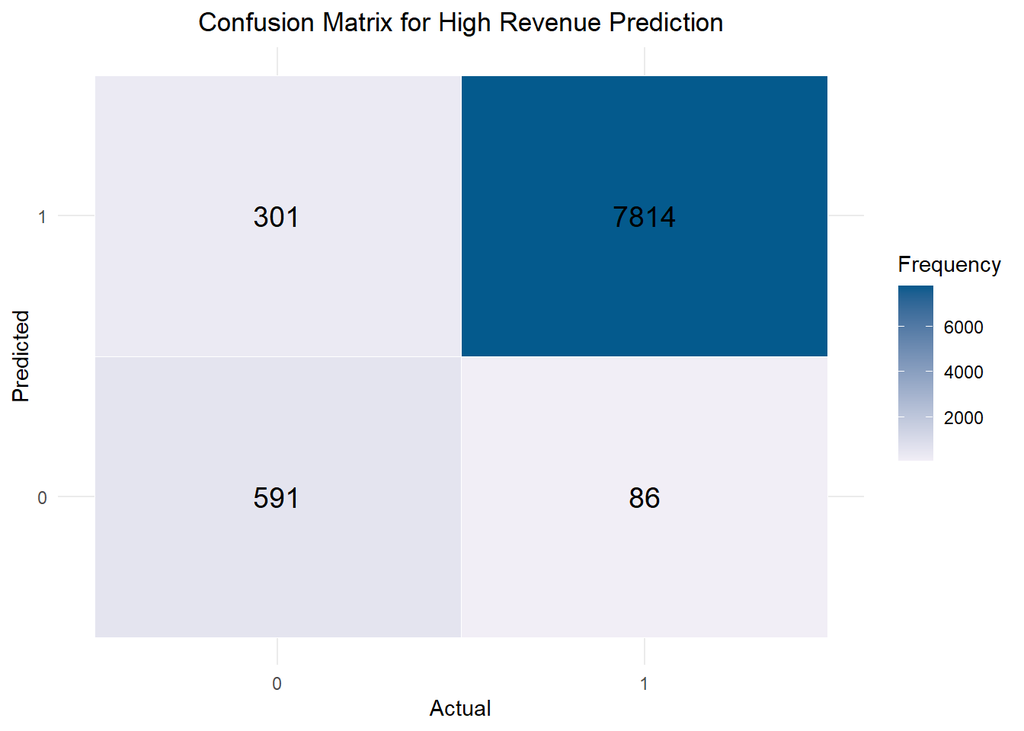

- **True Negatives (TN)**: 591
- **False Positives (FP)**: 301
- **False Negatives (FN)**: 86
- **True Positives (TP)**: 7814

#### Model Statistics

```r
# Extract relevant statistics from the confusion matrix object
stats <- data.frame(
  Metric = c("Accuracy", "95% CI", "Kappa", "Sensitivity", "Specificity", "Pos Pred Value",
             "Neg Pred Value", "Prevalence", "Detection Rate", "Balanced Accuracy"),
  Value = c(
    round(conf_matrix$overall['Accuracy'], 3),
    paste0("(", round(conf_matrix$overall['AccuracyLower'], 3), ", ", round(conf_matrix$overall['AccuracyUpper'], 3), ")"),
    round(conf_matrix$overall['Kappa'], 3),
    round(conf_matrix$byClass['Sensitivity'], 5),
    round(conf_matrix$byClass['Specificity'], 5),
    round(conf_matrix$byClass['Pos Pred Value'], 5),
    round(conf_matrix$byClass['Neg Pred Value'], 5),
    round(conf_matrix$byClass['Prevalence'], 5),
    round(conf_matrix$byClass['Detection Rate'], 5),
    round(conf_matrix$byClass['Balanced Accuracy'], 5)
  )
)

# Display Model Statistics
stats %>%
  kable("html") %>%
  kable_styling(full_width = F, position = "center", bootstrap_options = c("striped", "hover"))
```

Table 2: Model Statistics

|  | Metric | Value |
| --- | --- | --- |
| Accuracy | Accuracy | 0.956 |
|  | 95% CI | (0.951, 0.96) |
| Kappa | Kappa | 0.73 |
| Sensitivity | Sensitivity | 0.98911 |
| Specificity | Specificity | 0.66256 |
| Pos Pred Value | Pos Pred Value | 0.96291 |
| Neg Pred Value | Neg Pred Value | 0.87297 |
| Prevalence | Prevalence | 0.89854 |
| Detection Rate | Detection Rate | 0.88876 |
| Balanced Accuracy | Balanced Accuracy | 0.82583 |

- **Accuracy: 95.6%**
  - Indicates that 95.6% of all predictions (both high-revenue and non-high-revenue OPCOs) were correct.
- **Balanced Accuracy: 82.6%**
  - Provides an average of sensitivity and specificity, showing the model’s ability to handle imbalanced data by considering both true positive and true negative rates equally.
- **Kappa: 0.73**
  - Measures the agreement between the predicted and actual classifications while accounting for the possibility of random chance. A value of 0.73 indicates substantial agreement.
- **Sensitivity: 98.9%**
  - Represents the model’s ability to correctly identify high-revenue OPCOs. About 98.9% of true high-revenue cases were correctly predicted, which is great news for our stakeholders.
- **Specificity: 66.3%**
  - Indicates the model’s effectiveness in correctly identifying non-high-revenue OPCOs. 66.3% of true non-high-revenue cases were accurately classified. Not terrible, considering we’re not focused on this group for marketing purposes.
- **AUC: 0.826**
  - The Area Under the ROC Curve (AUC) shows the model’s ability to distinguish between high-revenue and non-high-revenue OPCOs. A value of 0.826 suggests good discriminative power.

### ROC Curve Analysis

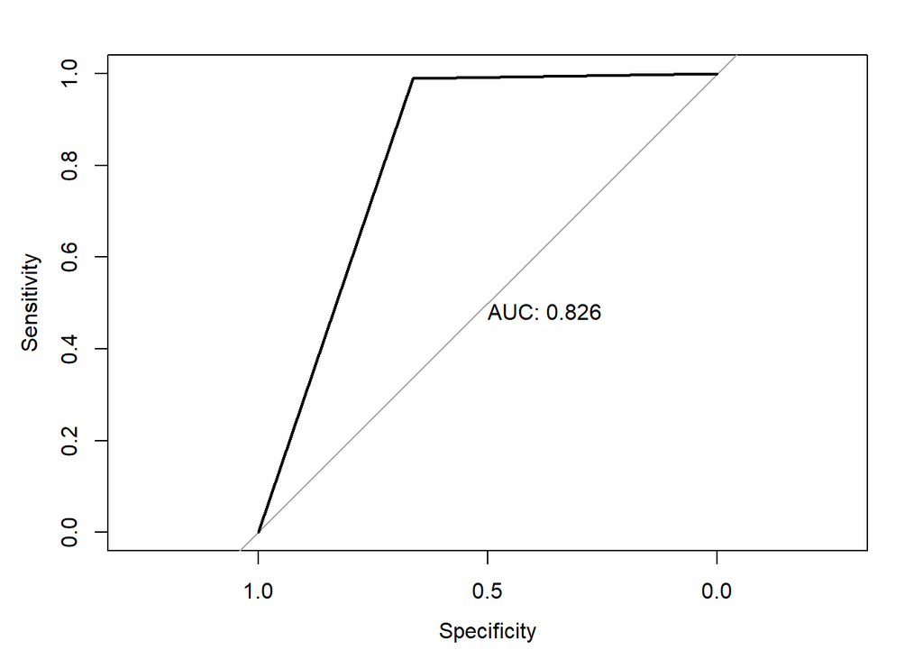

Figure 1: ROC Curve for High Revenue Prediction

```r
# ROC Curve and AUC
library(pROC)
roc_curve <- roc(as.numeric(test_target), as.numeric(test_pred))
plot.roc(roc_curve, print.auc = TRUE)
```

The ROC curve shows that the model has an AUC of 0.826, indicating good discriminative ability. This suggests that the model can reliably differentiate between high-revenue and non-high-revenue OPCOs.

### Feature Importance

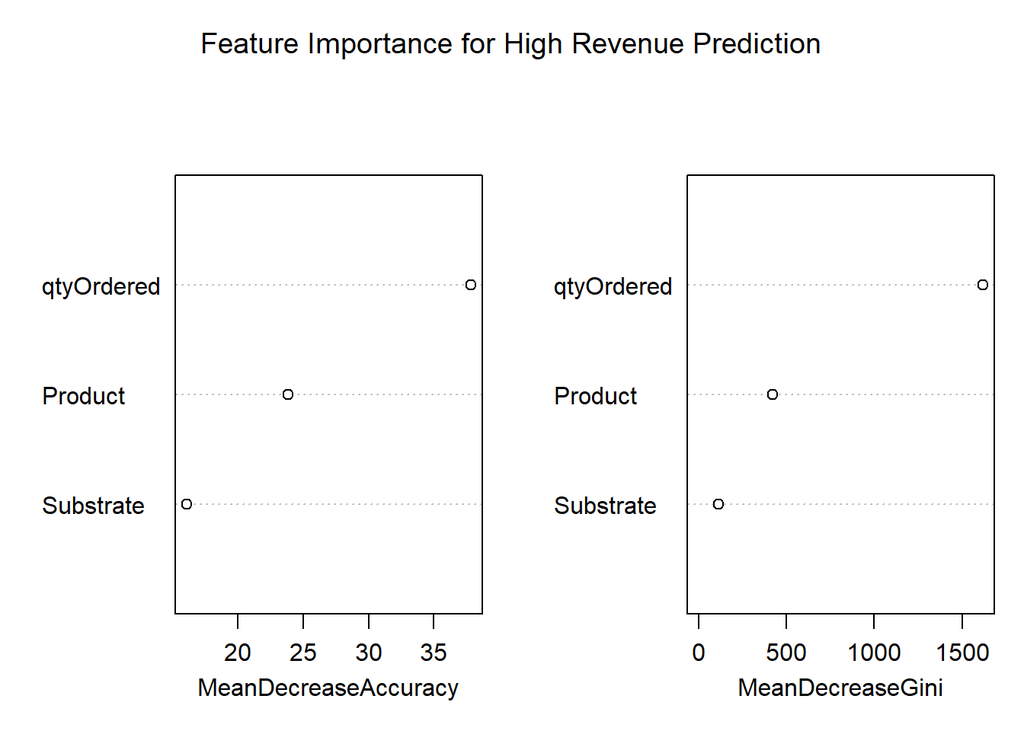

Figure 2: Feature Importance for High Revenue Prediction

```r
# Plot Mean Decrease in Accuracy and Mean Decrease in Gini
varImpPlot(rf_model, main = "Feature Importance for High Revenue Prediction")
```

The most critical features contributing to the model’s predictive power are:

- **`qtyOrdered`**: The strongest predictor of whether an OPCO is a high-revenue generator.
- **`Product`**: Indicates the type of product and its influence on revenue generation.
- **`Substrate`**: Plays a meaningful role but has less impact compared to `qtyOrdered` and `Product`.

## Conclusion

Using this information, decision-makers will be able to predict with fair accuracy where to put their marketing dollars in future campaigns. There is also plenty of room for improvements. Gathering more information and effectively introducing newer predictors could further enhance the model.

## References

[1]

C. J. Mantas, J. G. Castellano, S. Moral-Garcı́a, and J. Abellán, “A comparison of random forest based algorithms: Random credal random forest versus oblique random forest,” *Soft Comput.*, vol. 23, no. 21, pp. 10739–10754, Nov. 2019.

[2]

T. M. Khoshgoftaar, M. Golawala, and J. Van Hulse, “An empirical study of learning from imbalanced data using random forest,” in *19th IEEE international conference on tools with artificial Intelligence(ICTAI 2007)*, Patras, Greece: IEEE, Oct. 2007.

[3]

G. Biau and E. Scornet, “A random forest guided tour,” *Test (Madr.)*, vol. 25, no. 2, pp. 197–227, Jun. 2016.

[4]

B. Lariviere and D. Vandenpoel, “Predicting customer retention and profitability by using random forests and regression forests techniques,” *Expert Syst. Appl.*, vol. 29, no. 2, pp. 472–484, Aug. 2005.

[5]

J.-S. Hong, H. Yeo, N.-W. Cho, and T. Ahn, “Identification of core suppliers based on e-invoice data using supervised machine learning,” *J. Risk Fin. Manag.*, vol. 11, no. 4, p. 70, Oct. 2018.

[6]

K. Torizuka, H. Oi, F. Saitoh, and S. Ishizu, “Benefit segmentation of online customer reviews using random forest,” in *2018 IEEE international conference on industrial engineering and engineering management (IEEM)*, Bangkok: IEEE, Dec. 2018.

[7]

Stutti, “Dataset for random forest classification analysis.” Personal communication, 2024.

[8]

L. Breiman, “RANDOM FORESTS.” https://www.stat.berkeley.edu/~breiman/randomforest2001.pdf.

[9]

R Core Team, *R: A language and environment for statistical computing*. Vienna, Austria: R Foundation for Statistical Computing, 2024. Available: https://www.R-project.org/

[10]

A. Liaw and M. Wiener, “Classification and regression by randomForest,” *R News*, vol. 2, no. 3, pp. 18–22, 2002, Available: https://CRAN.R-project.org/doc/Rnews/

[11]

H. Wickham, R. François, L. Henry, K. Müller, and D. Vaughan, *Dplyr: A grammar of data manipulation*. 2023. Available: https://CRAN.R-project.org/package=dplyr

[12]

Kuhn and Max, “Building predictive models in r using the caret package,” *Journal of Statistical Software*, vol. 28, no. 5, pp. 1–26, 2008, doi: 10.18637/jss.v028.i05.

[13]

X. Robin *et al.*, “pROC: An open-source package for r and s+ to analyze and compare ROC curves,” *BMC Bioinformatics*, vol. 12, p. 77, 2011.